# Event History Analysis: ikke-parametriske metoder (*K*aplan *M*eier)

## Dagen program

- Kaplan-Meier estimation.
  - *Univariat* og *forskel mellem grupper*.
- Analyse og visualisering i `R`.
- Introduktion til `registerdata`-sættet og hvordan i går til det resten af kurset.
- Øvelser.

## Forventet udbytte

### *Viden*

- Introduktion til `R`-pakker relevant for *forløbsanalyseanalyse*.
- Introduktion til test for forskelle mellem grupper

### *Færdigheder*

- Forbered data til overlevelsesanalyse.
- **Datamanagement** i `R`.
- **Kaplan-Meier** overlevelsesanalyse i `R`.
- **Visualisering** af overlevelsesdata.

### *Kompetancer*

- `Kaplan-Meier` overlevelsesanalyse i R (`univariat` og `bivariat`, inkl. `test af forskelle`).

# Opsummering af grundbegreber og koncepter

## Beskrivende statistik

#### `Overlevelse` som funktion af tiden udtrykkes som:

$$S(t) = Pr(T > t)$$

#### `Hazard-raten` udtrykkes som:

$$h(t)$$

og

$$h(t) \Rightarrow 0 \: \text{to} \: \infty$$
da det er en rate og ikke en sandsynlighed.

#### `Median leveltid` udtrykkes som:

$$S(t) = 0,5$$

## `Overlevelse` er et udtryk for …

sandsynligheden for, at den **tid**, der går fra start af forløbet til hændelsen, **overstiger** et givet tidspunkt $t$. Det vil sige, sandsynligheden for at hændelsen endnu **ikke** er indtrådt ved $t$.

$$P \left ( \left \{ T > t \right \} \right )$$

$T$ er en stokastisk variabel, der repræsenterer **tiden til hændelsen**.

Denne sandsynlighed er givet som integralet under den tilhørende sandsynlighedstæthedsfunktion (**pdf**), $f(u)$, for alle tider $u$ større end $t$:

$$S(t) = P(\{T>t\}) = \int_{t}^{\infty} f(t)dt$$

## Hazard-raten er et udtryk for …

sandsynligheden for, at en begivenhed indtræffer inden for et kort tidsinterval, **betinget af**, at “enheden” har **overlevet** indtil starten af dette **interval**. Med andre ord, det er et udtryk for den den øjeblikkelige “styrke” eller risiko for hændelsen, udtrykt som:

$$h(t) = \frac{f(t)}{S(t)}$$

hvor $f(t)$ er sandsynlighedstætheden (**pdf**) for **hændelsestiden**, og $S(t)$ er **overlevelsesfunktionen** (se forrige slide).

## Median leveltid er et udtryk for …

den **tidligste tid**, hvor **halvdelen** af populationen eller samplet har oplevet **begivenheden**. Det vil sige, at vi finder $t$ (den afhængige variabel i overlevelsesanalysen), hvor:

$$\hat{S}(t) = 0,5$$

Denne værdi angiver det **punkt**, hvor $50\%$ af enhederne har oplevet hændelsen og $50\%$ fortsat er “overlevende”.

Medianen er ofte et foretrukket mål for central tendens i overlevelsesanalyser, fordi gennemsnittet kan blive nedad-biased, specielt når der er en betydelig andel af højre-censurerede observationer.

## Median leveltid er et udtryk for …

### Kode

```r
df <- read_csv("flytte.csv")

fit <- survfit2(Surv(dur, status) ~ 1, data = df)

median_over_tid <- 82

median_plot <-
  ggsurvplot(fit, data = df,
           title = "Overlevelseskurve ('flytte.csv' data fra Moodle)",
           palette = "#da1f66",
           xlab = TeX("Tid ($t$)"),
           ylab = TeX("$\\hat{S}(t)$"),
           linetype = "solid",
           surv.median.line = "hv",
           pval = FALSE,
           risk.table = FALSE)

plt <-
  median_plot[["plot"]] +
  annotate("text", x = 0, y = 0.2,
           label = paste(" Median overlevelsestid:\n", round(median_over_tid, 2), "uger"),
           color = "#003fa3", hjust = 0, vjust = -0.5) +
  guides(color = FALSE,
         fill = FALSE) +
  theme_minimal()
```

### Output

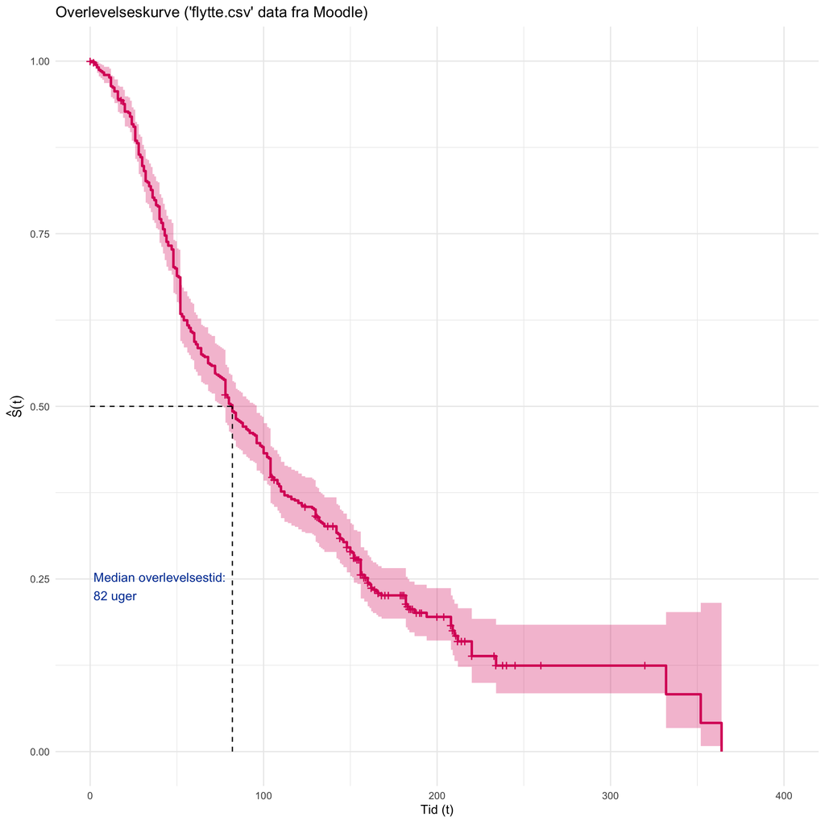

## Det vi skal huske er: (1)

1. $S(t)$ er et mål for **overlevelse som en funktion af tiden**. Med andre ord, hvor længe man bliver i en pågældende position. Funktionen beskriver altså hvor stor en andel af populationen der stadig ikke har oplevet hændelsen ved tiden $t$. Funktionen kan ses som et **produkt af de betingede overlevelsessandsynligheder i hvert enkelt tidsinterval** (overlevelsessandsynligheden i alle de foregående tider ganget sammen). *Fortæller noget om den samlede udvikling i “overlevelseschancen” over tid*.

## Det vi skal huske er: (2)

2. $h(t)$ fortæller noget om forekomsten af hændelser — forudsat personen har “overlevet” frem til tidsintervallet — samt hvordan det udvikler sig over tid. Med andre ord, funktionen udtrykker den øjeblikkelige risiko for, at hændelsen indtræffer i et **kort tidsinterval** omkring tidspunktet $t$, forudsat at hændelsen endnu ikke har fundet sted før $t$. Dette betyder, at $h(t)$ beskriver “styrken” af hændelsesrisikoen på netop dét tidspunkt og beskriver hvordan risikoen udvikler sig i hvert enkelt **tidsinterval**. *Fortæller noget om udviklingen i de enkelte tidsintervaller*.

## Det vi skal huske er: (3)

3. $S(t) = 0,5$, *median overlevelstiden*, fortæller hvornår halvdelen af sample/population har oplevet hændelsen (og omvendt ikke længere er under risiko for at opleve hændelsen). Altså, år overlevelsesfunktionen når værdien $0,5$. Dette punkt er et mål for, hvornår begivenheden **typisk indtræffer**. *Fortæller noget om ét enkelt punkt på kurven*.

# Kaplan-Meier estimation

## Kaplan-Meier (1.1)

Med eksemplet fra øvelsen:

Kaplan-Meier-metoden (`KM`), er en **non-parametrisk** metode. Det betyder, at metoden estimerer **overlevelsessandsynligheden** uden at lave forudgående antagelser om, hvordan de **underliggende overlevelsestider er fordelt**. Metoden estimerer den **kumulative overlevelsesfunktion** baseret på de observerede “overlevelses”-tider (her betegnet som `dur`) i populationen (`df`).

$$\hat{S}(t) = \prod_{i: t_i < t} \left(1 - \frac{d_j}{n_j}\right)$$

hvor,

- $\hat{S}(t)$, **overlevelsesfuntionen**, er den estimerede sandsynlighed for, at en person stadig “overlever” (ikke har oplevet hændelsen) ved tid $t$.
- $d_{j}$ er antallet af observerede hændelser (fx flyt) ved tidspunkt $t_{j}$.
- $t_{j}$ er observede tidspunkter for begivenheden (eng.: *failure times*).
- $n_{j}$ er antallet af individer, der er i risiko (altså endnu ikke har oplevet hændelsen eller er censureret) lige før tidspunkt $t_{j}$.

## Kaplan-Meier (1.2)

Kaplan-Meier-metoden (`KM`), er en **non-parametrisk** metode. Det betyder, at metoden estimerer **overlevelsessandsynligheden** uden at lave forudgående antagelser om, hvordan de **underliggende overlevelsestider er fordelt**. Metoden estimerer den **kumulative overlevelsesfunktion** baseret på de observerede “overlevelses”-tider (her betegnet som `dur`) i populationen (`df`).

$$\hat{S}(t) = \prod_{i: t_i < t} \left(1 - \frac{d_j}{n_j}\right)$$

Med andre ord, vi multiplicere overlevelsessandsynlighederne for hvert diskret tidsinterval — *uger* — hvor flyt finder sted. For hvert diskrete tidspunkt, $t_{j}$, estimeres overlevelsessandsynligheden som produktet af overlevelsessandsynlighederne op til det tidspunkt, ud fra forholdet mellem antallet af hændelser, $d_{j}$, og antallet af personer i risiko op til det tidspunkt, $n_{j}$.

## Kaplan-Meier (1.3)

Kaplan-Meier-metoden (`KM`), er en **non-parametrisk** metode. Det betyder, at metoden estimerer **overlevelsessandsynligheden** uden at lave forudgående antagelser om, hvordan de **underliggende overlevelsestider er fordelt**. Metoden estimerer den **kumulative overlevelsesfunktion** baseret på de observerede “overlevelses”-tider (her betegnet som `dur`) i populationen (`df`).

$$\hat{S}(t) = \prod_{i: t_i < t} \left(1 - \frac{d_j}{n_j}\right)$$

Det særlige ved denne metode er, at den **udnytter al information frem til et eventuelt censoreringspunkt**, fremfor at droppe de individer/observationer, der er **censureret** på et senere tidspunkt. Det vil sige, at selvom nogle individer ikke observeres indtil hændelsen (i.e., de censureres), indgår de stadig i beregningen, indtil det tidspunkt de censureres. Dette står i kontrast til nogle klassiske regressionsmetoder, hvor censurerede observationer ofte udelades.

## Kaplan-Meier (2.1)

Én gang til,

- $d_{j}$ er antallet af hændelser i det diskrete tidsinterval.
- $n_{j}$ er antallet af person i `risikosættet`. Dvs. antallet af personer, der ikke har oplevet **hændelsen** *eller* blevet **censureret** op til tid $j$. Det vil sige at $S(t)$ er udledt af `risikosættet`: ofte refereret til som $R(t)$.
- $1 - \frac{d_j}{n_j}$ er sandsynlighed for overlevelse, *betinget* af overlevelse frem til $j$.

Som angivet ved $\prod_{i: t_i < t}$ ganger vi overlevelsessandsynligheder frem til det pågældende tidspunkt, $j$.

## Kaplan-Meier (2.2)

Som angivet ved $\prod_{i: t_i < t}$ ganger vi overlevelsessandsynligheder frem til det pågældende tidspunkt, $j$.

Regneeksempel med de økonomistuderende i “flyttedataen”

| `Tid`, $t$ | `Risikosæt` $n_{i}$ | `Hændelser` $d_{j}$ | $n_{j}-d_{j}$ | $\frac{n_{j}-d_{j}}{n_{j}}$ | $\hat{S}(t_{j})$ |
| --- | --- | --- | --- | --- | --- |
| 0 | 77 | 0 | 0 | 1 | $\hat{S}(t_{0})=1$ |
| 1 | 77 | 4 | 73 | $1 \times \frac{73}{77}$ | $\hat{S}(t_{1})=0,95$ |
| 2 | 73 | 10 | 63 | $0,95 \times \frac{63}{73}$ | $\hat{S}(t_{2})=0,82$ |
| 3 | 63 | 14 | 49 | $0,82 \times \frac{49}{63}$ | $\hat{S}(t_{3})=0,64$ |
| 4 | 49 | 8 | 41 | $0,64 \times \frac{41}{49}$ | $\hat{S}(t_{4})=0,53$ |
| 5 | 41 | 6 | 35 | $0,53 \times \frac{35}{41}$ | $\hat{S}(t_{5})=0,45$ |
| $j$ | … | … | … | … | $\hat{S}(t_{j})=0$ |

$\hat{S}(t)$ vil **altid** være faldende eller konstant. Aldrig stigende.

Kaplan-Meier kaldes også ofte *the product-limit estimator*, fordi vi beregner overlevelsesfunktionen som et **produkt af betingede overlevelsessandsynligheder**.

## Kaplan-Meier (2.3)

$$\hat{S}(3) = \frac{73}{77} \times \frac{63}{73} \times \frac{49}{63} = 0,64$$

$$\hat{S}(4) = \frac{73}{77} \times \frac{63}{73} \times \frac{49}{63} \times \frac{41}{49} = 0,53$$

# Kaplan-Meier: Stratificering

## Kaplan-Meier (3.1)

*Et af de typiske formål med en KM estimation, er at sammeligne to overlevelseskurver.* Vi gør dette ved at tilføje en uafhængig variabel i stedet for `1` (intercept-only model).

- `Stratificering`: Dataene opdeles baseret på en covariate (fx årgang eller bopælsområde), hvorefter der udregnes separate KM-kurver for hver gruppe. Disse kurver kan derefter **sammenlignes visuelt**, og en **log-rank test** kan anvendes til at afgøre, om **forskellene mellem kurverne** er signifikante.

## Kaplan-Meier (3.2)

*Et af de typiske formål med en KM estimation, er at sammeligne to overlevelseskurver.* Vi gør dette ved at tilføje en uafhængig variabel i stedet for `1` (intercept-only model).

### Kode

```r
fit <- survfit2(Surv(dur, status) ~ udd, data = df)

strat_plot <-
  ggsurvplot(fit, data = df,
           title = "Overlevelseskurve ('flytte.csv' data fra Moodle)",
           palette = c("#da1f66", "#003fa3"),
           xlab = TeX("Tid ($t$)"),
           ylab = TeX("$\\hat{S}(t)$"),
           linetype = "solid",
           surv.median.line = c("hv") ,
           conf.int = TRUE,
           pval = FALSE,
           risk.table = FALSE)

plt <-
  strat_plot[["plot"]] +
  theme_minimal()
```

### Output

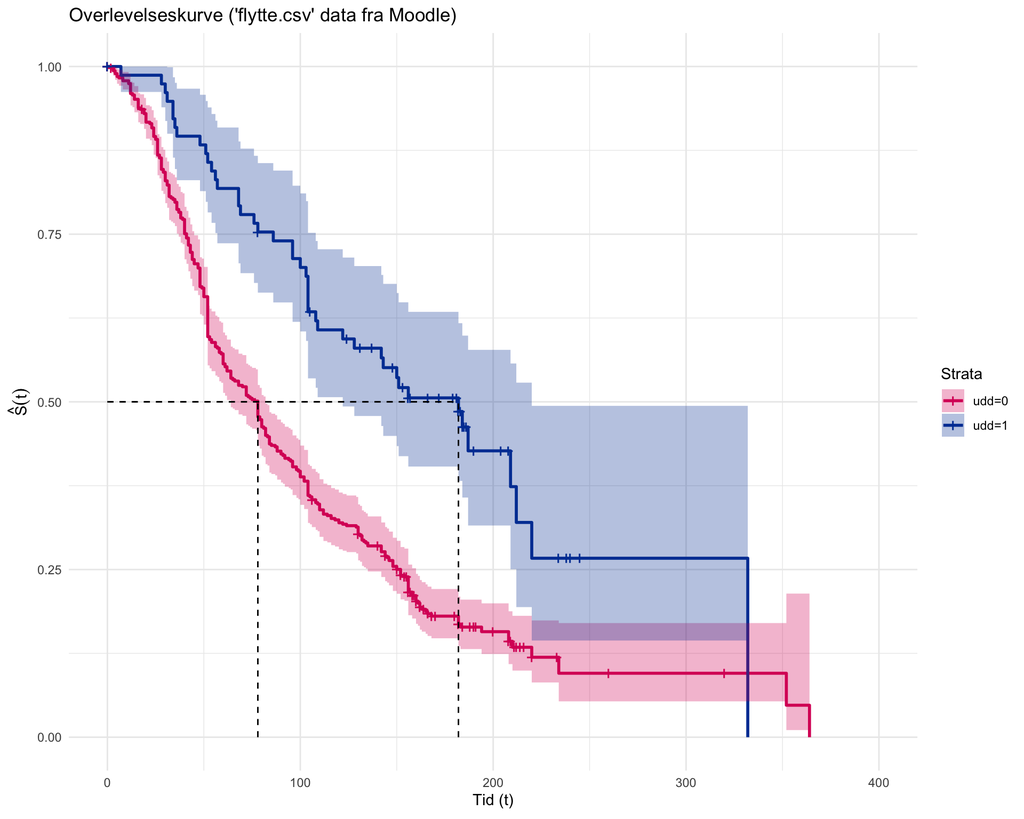

## Kaplan-Meier (3.3)

Når vi **stratificerer data**, estimerer vi en separat `KM`-kurve for hvert stratum. For et givet stratum $k$ er den estimerede overlevelsesfunktion defineret som:

$$\hat{S}_k(t) = \prod_{j: t_j \le t} \left(1 - \frac{d_{j,k}}{n_{j,k}}\right)$$

## Kaplan-Meier (4)

```r
fit <- survfit2(Surv(dur, status) ~ udd, data = df)

fit
```

```
Call: survfit(formula = Surv(dur, status) ~ udd, data = df)

        n events median 0.95LCL 0.95UCL
udd=0 474    390     78      64      82
udd=1  79     44    182     122     220
```

## Kaplan-Meier (5)

```r
fit <- survfit2(Surv(dur, status) ~ udd, data = df)

summary(fit)
```

```
Call: survfit(formula = Surv(dur, status) ~ udd, data = df)

                udd=0
 time n.risk n.event survival std.err lower 95% CI upper 95% CI
    2    472       1   0.9979 0.00212       0.9937        1.000
    3    469       2   0.9936 0.00367       0.9865        1.000
    4    467       2   0.9894 0.00473       0.9801        0.999
    5    465       2   0.9851 0.00558       0.9742        0.996
    6    463       1   0.9830 0.00596       0.9714        0.995
    8    462       2   0.9787 0.00665       0.9658        0.992
   11    460       2   0.9745 0.00727       0.9603        0.989
   12    458       7   0.9596 0.00908       0.9419        0.978
   13    451       1   0.9575 0.00931       0.9394        0.976
   14    450       3   0.9511 0.00995       0.9318        0.971
   16    447       6   0.9383 0.01110       0.9168        0.960
```

[output cut: 158 more lines]

## Hvorfor sammenligne? (1)

- Har forskellige grupper forskellig overlevelse?
- Første skridt i undersøgelsen af *hvorfor* (i et `kausalt henseende`). (…) Dette kan dog ikke besvares med *KM*, som vi vil vende tilbage til.

## Hvorfor sammenligne? (2)

Vi tester følgende `nul-hypotese`:

$$H_{0}: S_{1}(t)=S_{2}(t)=\dots=S_{n}(t)$$

Med andre ord:

- `Nul-hypotese` — **Overlevelsesfunktionerne** for de forskellige grupper er ens. I en to-gruppesammenligning: $H_{0}: S_{1}=S_{2}$
- `Alternativ hypotese` — **Overlevelsesfunktionerne** er forskellige. Dvs. **mindst to** af dem er **forskellige**: $H_{1}: S_{1} \neq S_{2}$

Ved flere grupper er logikken den samme. **Alle** overlevelsesfunktioner **er ens** eller **mindst to** overlevelsesfunktioner **er forskellige**

## Hvordan sammenligner vi? (1)

- `Visuelt`.
- `signifikanstests`: Der er forskellige tests, men `log-rank` (Mantel-Haenszel) test er den mest anvendte.

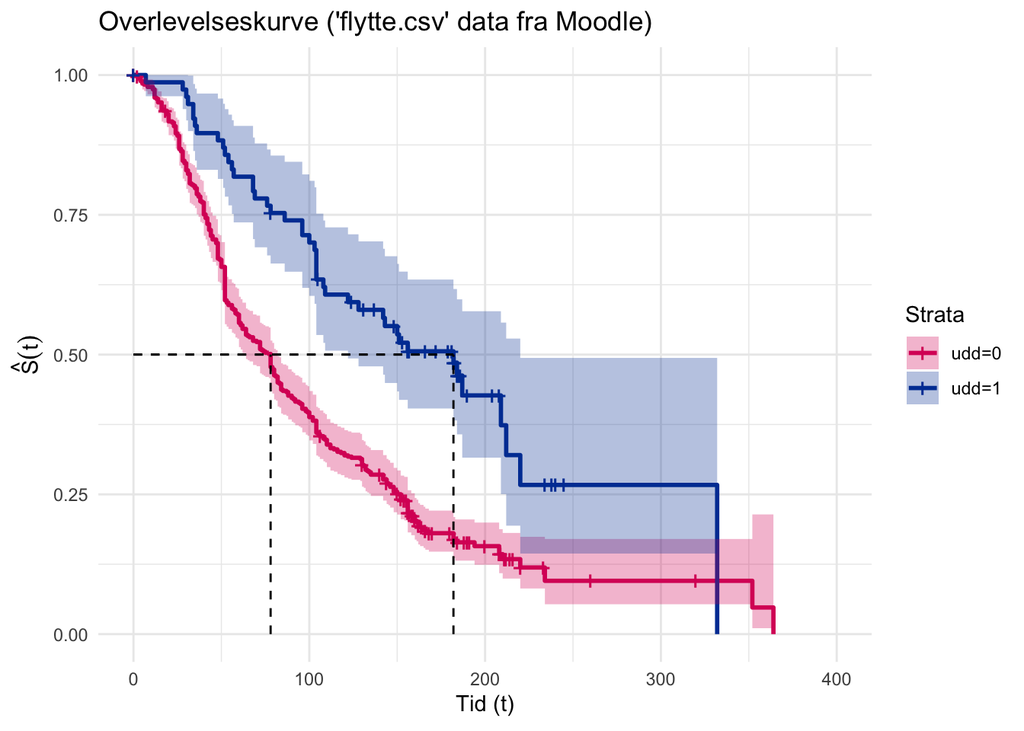

## Hvordan sammenligner vi? (2.1)

- Teknisk er en log-rank test en “`large scale chi-squared test`”, $\chi^{2}$-test, der estimerer en overordnet—global—sammenligning af to eller flere *KM* kurver.
- Det gør vi ved at udvide de forrige tabeller—tabellerne med *tid*, *hændelse*, *risksæt*, *censureringer*, osv.—til også at inkludere `forventede antal hændelser`. Forventede hændelser, $e$, for hver gruppe, er givet ved:

$$e_{1} = \left ( \frac{n_{1}}{n_{1}+n_{2}} \right ) \times \left ( d_{1}+d_{2} \right )$$

og

$$e_{2} = \left ( \frac{n_{1}}{n_{1}+n_{2}} \right ) \times \left ( d_{1}+d_{2} \right )$$

hvor $n_{1}$ og $n_{2}$ er antallet af individer i risiko i hver gruppe, og $d_{1}$ og $d_{2}$ er de observerede hændelser.

## Hvordan sammenligner vi? (2.2)

Herfra kan vi udregne forskellen i observeret $O$ og forventet $E$, som:

$$O_{i}-E_{i}=\sum \left ( d_{i} - e_{i} \right )$$

hvor $i\in1,2$.

Summen for de to grupper er spejlvendte (det ene med et minus) på grund af, at den samlede afvigelse skal summeres til nul.

## Hvordan sammenligner vi? (3)

Log-rank statistikken for to grupper $(1, 2)$ er slutteligt givet ved:

$$\chi^{2} = \frac{\left ( O_{1} - E_{1}\right )^{2} }{\text{Var} \left ( O_{1} - E_{1} \right ) }$$
eller

$$\chi^{2} = \frac{\left ( O_{2} - E_{2}\right )^{2} }{\text{Var} \left ( O_{2} - E_{2} \right ) }$$

P-værdien udleder vi fra $\chi^{2}$ fordelingen på klassisk vis. **Dette lader vi selvfølgelig computeren gøre, og printes ofte i bunden eller toppen af outputtet, afhængigt af kode-sprog**.

## Hvordan sammenligner vi? (4)

Alternative til `log-rank` er `Wilcoxon`, `Tarone-Ware`, `Peto`, og `Flemington-Harrington` tests.

Disse er alle variationer af log-rank testen med har forskellige vægte, der hhv. lægge større vægt på tidlige eller sene hændelser i forløbet. God praksis er at vælge en test *a priori* baseret på forventninger om dataen og fænoment. Disse forventninger kan trykprøves ved også at lave de alternative tests. Ofte vil de andre test have samme signifikans-niveau.

## Hvordan sammenligner vi? (5)

```r
survdiff(Surv(dur, status) ~ udd, data = df)
```

```
Call:
survdiff(formula = Surv(dur, status) ~ udd, data = df)

        N Observed Expected (O-E)^2/E (O-E)^2/V
udd=0 474      390    348.2      5.01      26.3
udd=1  79       44     85.8     20.34      26.3

 Chisq= 26.3  on 1 degrees of freedom, p= 0.0000003
```

$$\chi^{2} \approx \sum_{i}^{\# \: \text{antal grupper}} \frac{(O_{i}-E_{i})^{2} }{E_{i}}$$

se Kleinbaun og Klein (2020, s. 71).

# Overlevelsesdata og øvelse

## `single-episode file` med fixed/`time-invariant` variable:

```r
load("First_child.rda")
```

- `PNR` (individuel ID)
- `aar` (året for hændelsen)
- `ALDER` (alder på hændelsestidspunktet)
- `KOEN` (kønsvariabel – baseret på cpr)
- `f_udd` (højeste fuldførste uddannelse)
- `region18` (bopælsregion da personen er 18 år)
- `event` (1=hændelse, 0=uændret tilstand)

## `single-episode file`, klargøring af fil:

```r
load("First_child.rda")

data <-
  df %>%
  select(pnr, aar, ALDER, KOEN, C_ANTBOERNF, f_udd, region) %>%
  mutate(age = as.numeric(ALDER)) %>%
  filter(age >= 18) %>%
  mutate(person_start = case_when(lag(pnr) == pnr ~ 0, TRUE ~ 1)) %>%
  mutate(born = as.numeric(C_ANTBOERNF)) %>%
  mutate(kvinde = if_else(KOEN == 2, 1, 0)) %>%
  select(- C_ANTBOERNF, - KOEN, -ALDER) %>%
  mutate(event = if_else(lag(born) == 0 & born == 1, 1, 0)) %>%
  mutate(born_aar = if_else(event == 1, aar, 0)) %>%
  mutate(censor = if_else(event == 1 & aar < 2010 | aar == 2010 & event %in% c(1, 0), 1, 0)) %>%
  filter(censor == 1,
         kvinde == 1,
         born %in% c(1, 0)) %>%
  group_by(pnr) %>%
  slice_min(age) %>%
  ungroup() %>%
  filter(aar >= 1988,
         age < 40)

sum(data[["event"]], na.rm = TRUE)
mean(data[["age"]], na.rm = TRUE)
```

## Øvelse

*I skal undersøge tiden indtil første fødte barn*. Dette eksempel fortsætter gennem forelæsningerne, således i kan bygge ovenpå hver øvelse. MEN, har i lyst til at arbejde med en anden problemstilling i finder interressant, eller evt. matcher med jeres aktuelle projektarbejde, er i også velkomne til det.

1. Diskuter hvorfor variablene er fixed/“tids-invariante”? Hvorfor ikke?
2. Konstruer en meningsfuld tids-variabel ud fra `ALDER`, således alle starter i populationen under risiko (`tid = 1`), når de fyldte 18 år.

3.1 Lav en `KM` estimation: beskriv og fortolk resultaterne.

3.2 Lav en meningsfuld og *fyldestgørende* visualisering.

4. Test og visualiser om der er forskel mellem regioner (`region18`) i tiden indtil første fødte barn.

```r
df <- haven::read_sas("//Volumes//Fileshares//mikrooekonometri-F25//Råfiler//pnr_sample.sas7bdat")
```

Jeppe F. Qvist | 27. februar 2025